# Sampling Methods

Yuji Saikai ysaikai@unimelb.edu.au School of Mathematics and Statistics The University of Melbourne

These notes are based on Chapter 2.7 of Kroese, D. P., & Chan, J. C. (2014). *Statistical modeling and computation*. New York: Springer.

# Introduction

To use Monte Carlo methods, first we specify random variables and then take samples from them. In Monte Carlo integration, we mostly use only uniform and exponential distributions, for which we can simply call R built-in samplers (`runif` or `rexp`). In the last example, however, we sample from the non-standard distribution using one of the methods covered in these notes.

In general, sampling can be quite challenging as our models become complex. For example, after computing a posterior PDF using Bayes’ formula
$$f(\theta|\mathbf{x}) = \frac{f(\mathbf{x}|\theta)f(\theta)}{\int_\theta f(\mathbf{x}|\theta)f(\theta)d\theta},$$
we are most likely interested in the *posterior mean*
$$\mathbb{E}[\theta|\mathbf{x}] = \int_\theta \theta f(\theta|\mathbf{x})d\theta$$
or the *predictive distribution*
$$f(\tilde{x}|\mathbf{x}) = \int_\theta f(\tilde{x}|\theta,\mathbf{x})f(\theta|\mathbf{x})d\theta.$$
In many practical applications, MC integration is the approach to use. However, as you can imagine by noticing the product and division involved in the formula, posterior PDFs can easily become unwieldy. Thus, we need methods to sample from non-standard and often unwieldy PDFs.

We cover three sampling methods in ascending order of sophistication:

- Inverse transform method
- Acceptance-rejection method
- Markov chain Monte Carlo (in separate notes)

# Inverse transform method

The method is applicable only to cases in which we can invert CDFs. If applicable, it is fast and reliable.

## Invertible CDFs

To illustrate the idea, consider a case where $F$ as the CDF for $X$ is invertible (e.g., $X\sim \text{N}(0,1)$). Then, given $U\sim \text{U}(0,1)$, the CDF for a transformed random variable $Y=F^{-1}(U)$ turns out to be the same CDF for $X$.

$$\begin{align}
P(Y\leq y) &= P(F^{-1}(U)\leq y)\\
&= P(U\leq F(y))\\
&= F(y)\\
&= P(X\leq y)
\end{align}$$

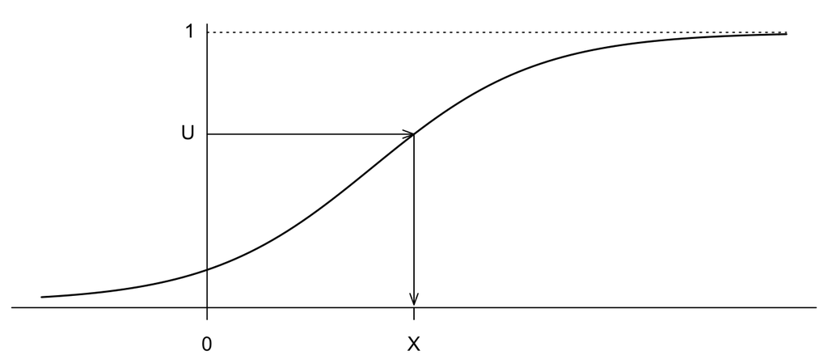

```r
f <- function(x) 1/(1+exp(-(x-2)))

par(mar=c(2,.5,1,.5))
curve(1/(1+exp(-(x-2))), from=-2, to=7, lwd=1.5, axes=FALSE, ann=FALSE)
axis(side=1, at=c(-4,0,2.5,8), labels=c("","0","X",""))
abline(v=0)
lines(c(0,7), c(1,1), lty=3)
arrows(0, f(2.5), 2.5, f(2.5),length=.1,angle=20)
arrows(2.5, f(2.5), 2.5, -.01,length=.1,angle=20)
text(0, f(2.5), "U", pos=2)
text(0, 1, "1", pos=2)
```

Since CDFs completely characterise random variables, the identical CDFs between $X$ and $Y$ means that, to sample from $X$, we may sample from $Y$. Given the knowledge of $F^{-1}$, it is easy to sample from $Y$:

1. sample $u$ from $U[0,1]$, and
2. transform $u$ to get a sample $y=F^{-1}(u)$ from $Y$.

> Note that the definition $Y=F^{-1}(U)$ implies $U=F(Y)$. Since $X$ and $Y$ have the same distribution and $X$ is an arbitrary continuous random variable, we have $U=F(X)$ — if we transform an arbitrary $X$ using its CDF, we have a random variable of $U(0,1)$.

## Invertible CDFs over the support

CDFs for many random variables are technically not invertible. Remember the definition of a random variable — a function whose co-domain is $\mathbb{R}$ — and the domain of $F$ is $\mathbb{R}$. Thus, to be invertible, $F$ must be **strictly increasing** over $\mathbb{R}$. Equivalently, the support of $X$ must be $\mathbb{R}$. This condition excludes many random variables including Exponential and Gamma whose support is only the half real line.

However, we are interested in samples from the support $\mathcal{S}$ for $X$. So, we may just define $G$ on $\mathcal{S}$ such that $G(x)=F(x)$ for all $x\in\mathcal{S}$. Then, $G$ is invertible and we can generate a sample $G^{-1}(u)$ for $X$.

## CDFs for discretes

When $X$ is discrete, $F$ is a step function as below.

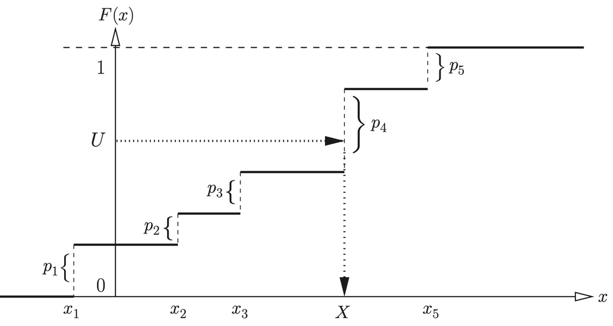

To deal with a more general case, we may use the following $H^{-1}:(0,1)\to\mathbb{R}$ to generate a sample $H^{-1}(u)$ for $X$:
$$H^{-1}: u \mapsto \inf\{x : F(x)\geq u\} .$$

Notice that $H^{-1}$ is a generalisation of $F^{-1}$ or $G^{-1}$, and it also works in those special cases.

> In practice, when $X$ has a finite support, we can use a R built-in function `sample(x, prob, ...)` by passing the desired PMF to `prob`.

## Example

Let’s generate samples from $\text{exp}(1)$ whose CDF is $F(x)=1-e^{-x}$ for $x\geq0$ and $0$ otherwise. Solving the following
$$\begin{alignat}{2}
&& u &= 1-e^{-x}\\
&\Leftrightarrow\quad & x &= -\log(1-u)\\
\end{alignat}$$
we find $G^{-1}(u) = -\log(1-u)$. Below is a histogram together with the PDF of $\text{exp}(1)$.

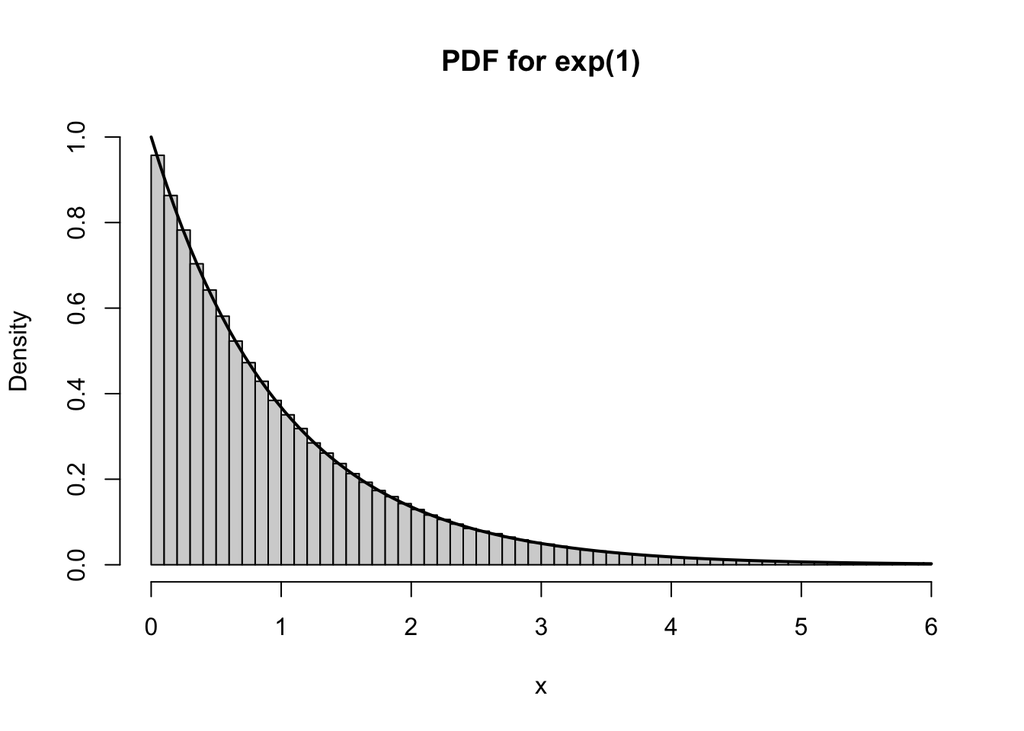

```r
n <- 1e6
u <- runif(n)
x_exp <- -log(u) # U and 1-U have the same distribution
x <- x_exp[x_exp<6] # Truncate for visualisation
hist(x, seq(0, 6, .1), freq=F, ylim=c(0,1), main="PDF for exp(1)")
curve(exp(-x), from=0, lwd=2, add=T)
```

> Another example is in the importance sampling example to sample from the PDF $f(x) = 0.5x^{-0.5}$.

# Acceptance-rejection method

Even when the inverse of $F$ exists, inverting $F$ is often analytically impossible or numerically too expensive (i.e. root finding at every evaluation of $F^{-1}(u)$). In these cases, we may try the acceptance-rejection method. The acceptance-rejection method is based on the following intuition.

*Obtain a random sample $(x,y)$ using uniform sampling from the region formed by the $x$-axis and the density curve of $X$. Then, keep $x$ as a sample from $X$.*

The beauty of this method is that we need not directly sample from the target PDF, but only uniformly sample from the region under the graph of the target PDF.

> Recall that, by uniform sampling from a set $A\subset\mathbb{R}^d$, we mean sampling from the joint PDF $f(x) = \mathbb{1}_A(x)/|A|$.

How can we obtain random samples uniformly taken from that region? A trick is to find another PDF $g$ that satisfies the following conditions:

- It is easy to sample from.
- There exists a constant $C>0$ such that $Cg(x)\geq f(x)$ for all $x\in\mathbb{R}$.

Given the PDF $g$,

1. sample $x$ from $g$, and
2. sample from $\text{U}(0, Cg(x))$.

If we keep only samples that fall under the curve $f(x)$, those samples $\{(x,y):0<y\leq f(x)\}$ are uniformly taken from the desired region.

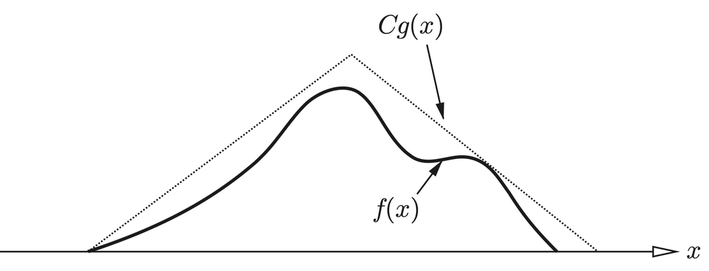

The claim is intuitive but may not be obvious. So, two key facts are stated as lemmas below.

## Example

Let’s generate samples from $X\sim \text{N}(0,1)$. There are two observations to make. Since the PDF is symmetric around $0$, once we generate positive samples, we can randomly flip their signs to generate negative samples. The PDF for the positive half can be derived by re-normalising the original PDF:
$$f(x) =
\begin{cases}
\sqrt{\frac{2}{\pi}}e^{-x^2/2} & x\geq0\\
0 & \text{otherwise}
\end{cases} .$$

The normalisation constant $\kappa = \sqrt{2/\pi}$ is obtained by the following
$$\begin{align}
1 &= \int_0^\infty \kappa e^{-x^2/2}dx\\
&= \kappa\int_0^\infty e^{-x^2/2}dx\\
&= \kappa\sqrt{\frac{\pi}{2}}.
\end{align}$$
The last equality is based on the right half of the standard normal PDF, which is symmetric about $0$,
$$\int_0^\infty \frac{1}{\sqrt{2\pi}}e^{-x^2/2}dx = \frac{1}{2}.$$

Next, notice that we can bound the above $f$ by $Cg(x)$ where $g$ is the PDF for $\text{exp}(1)$ and $C=\sqrt{2e/\pi}$.

> Notice $1 = {\operatorname{argmax}} \frac{f(x)}{g(x)}$ and $C = \frac{f(1)}{g(1)}$.

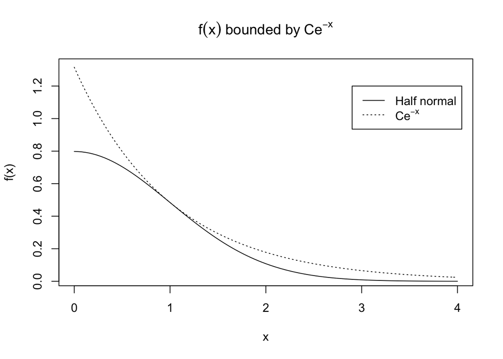

```r
curve(sqrt(2*exp(1)/pi)*exp(-x), from=0, to=4, ylab="f(x)", lty=3)
curve(sqrt(2/pi)*exp(-x^2/2), from=0, to=4, add=TRUE)
title(bquote(f(x) ~ "bounded by" ~ Ce^-x))
legend(2.9, 1.2, lty=c(1,3),
       legend=c("Half normal", expression(Ce^-x)))
```

Here is a result.

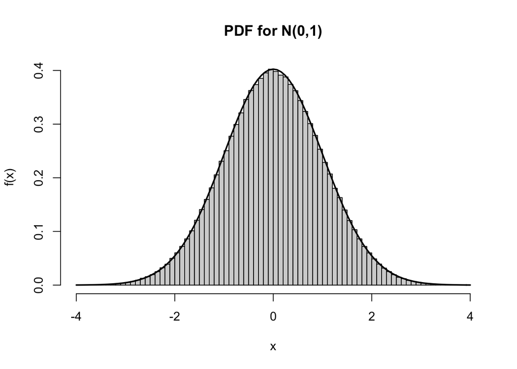

```r
half.normal <- function(x) sqrt(2/pi)*exp(-x^2/2)
C <- sqrt(2*exp(1)/pi)

y <- runif(length(x_exp))*C*exp(-x_exp) # Reuse x_exp from exp(1)
x_pos <- x_exp[y <= half.normal(x_exp)] # Keep those under the target PDF
ind <- 1:floor(length(x_pos)/2) # Half sample for negative values
x_neg <- -x_pos[ind]
x_pos <- x_pos[-ind]
x <- c(x_neg[x_neg>-4], x_pos[x_pos<4]) # truncate for visualisation
res <- hist(x, 100, freq=F, ylab="f(x)", xlim=c(-4,4), main="PDF for N(0,1)")
curve(max(res$density)*exp(-x^2/2), lwd=2, add=T)
```

## Lemma 1

*A uniform sample $(x,y)$ from the region under the curve $y=Cg(x)$ can be obtained by first sampling $x$ from the PDF $g$ and then sampling $y$ from $\text{U}(0,Cg(x))$ given $x$.*

Let $h$ be the conditional PDF for $Y|X=x$ following $\text{U}(0,Cg(x))$:
$$h(y|x) =
\begin{cases}
\frac{1}{Cg(x)} & y\in[0,Cg(x)]\\
0 & \text{otherwise}
\end{cases} .$$
Then, observe the following joint PDF for $(x,y)$:
$$\begin{align}
f(x,y) &= h(y|x)g(x)\\
&= \frac{1}{Cg(x)}g(x)\\
&= \frac{1}{C},
\end{align}$$
which implies the uniform joint distribution.

## Lemma 2

*Let $A,B\subset\mathbb{R}^2$ such that $A\subseteq B$. If $\{X_n\} = X_1,X_2,\dots$ is an IID sequence obtained by uniform sampling from $B$. Then, a subsequence $\{X_{n_k}\} = X_{n_1},X_{n_2},\dots$ such that $X_{n_k}\in A$ for all $k\geq1$ is an IID sequence obtained by uniform sampling from $A$.*

> When you watch the animation in Estimating $\pi$, don’t you think dots look uniformly distributed inside the quarter disk?

First, consider the probability that $X$ falls inside a small region $\Delta A\subset A$.
$$\begin{align}
P(X\in \Delta A |X\in A) &= \frac{P(X\in(\Delta A\cap A))}{P(X\in A)}\\
&= \frac{P(X\in \Delta A)}{P(X\in A)}\\
&= \frac{\int_{\Delta A}f_X(a)da}{\int_{A}f_X(a)da}
\end{align}$$

Then, by the fundamental theorem of calculus, the conditional density at $x\in \Delta A$ is:
$$\begin{align}
f_{X|A}(x|X\in A) &= \lim_{|\Delta A|\to 0} \frac{P(X\in \Delta A | X\in A)}{|\Delta A|}\\
&= \frac{1}{\int_{A}f_X(a)da} \lim_{|\Delta A|\to 0}\frac{\int_{\Delta A}f_X(a)da}{|\Delta A|}\\
&= \frac{f_X(x)}{\int_{A}f_X(a)da}\\
\end{align}$$

An implication is that, if $X$ is uniformly distributed over $B$,
$$\begin{align}
f_{X|A}(x|X\in A) &= \frac{\frac{1}{|B|}}{\frac{|A|}{|B|}}\\
&= \frac{1}{|A|}\\
\end{align}$$

which is a constant and integrates to $1$ over $A$. Hence, a subset of uniform samples from $B$ that also belong to $A$ are indeed uniformly distributed over $A$.